# Question

En una comunidad se realizó un estudio sobre el número de hijos por familia. Los resultados obtenidos se presentan en la siguiente tabla:

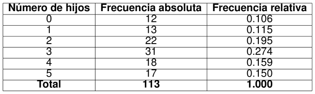

Con base en la información de la tabla, ¿cuál de las siguientes afirmaciones sobre la frecuencia relativa de las familias con 2 hijos es correcta?

## Answerlist

- El 22% de las familias tienen 2 hijos
- El 80.5% de las familias tienen 2 hijos
- El 19.5% de las familias tienen 2 hijos
- El 0.195% de las familias tienen 2 hijos

# Solution

Para interpretar correctamente la frecuencia relativa, debemos recordar que:

1. **Frecuencia relativa** = Frecuencia absoluta / Total de datos
2. La frecuencia relativa representa la proporción de datos en cada categoría
3. Para expresarla como porcentaje, multiplicamos por 100

**Análisis de la tabla:**

- Total de familias encuestadas: 113
- Familias con 2 hijos: 22
- Frecuencia relativa: 0.195

Por lo tanto, la interpretación correcta es: **El 19.5% de las familias tienen 2 hijos**

**Análisis de los distractores comunes:**

- Confundir frecuencia absoluta con porcentaje (usar directamente el número de familias como porcentaje)
- No convertir la frecuencia relativa a porcentaje (dejar el valor decimal)
- Calcular el porcentaje sobre una categoría diferente
- Calcular el porcentaje complementario (100% - porcentaje correcto)

Es fundamental distinguir entre: - **Frecuencia absoluta**: cantidad de casos - **Frecuencia relativa**: proporción respecto al total (valor entre 0 y 1) - **Porcentaje**: frecuencia relativa × 100

## Answerlist

- Falso. Esta no es la interpretación correcta de los datos.
- Falso. Esta no es la interpretación correcta de los datos.
- Verdadero. Esta es la interpretación correcta de la frecuencia relativa convertida a porcentaje.
- Falso. Esta no es la interpretación correcta de los datos.

# Meta-information

exname: Interpretación de frecuencia relativa en tabla de distribución extype: schoice exsolution: 0010 exshuffle: TRUE exsection: Estadística/Tablas de frecuencia/Interpretación exextra[icfes_competencia]: interpretacion_representacion exextra[icfes_componente]: aleatorio exextra[icfes_nivel]: 2 exextra[icfes_contexto]: comunitario